# Session 2: Representing networks

Edge lists, adjacency matrices, attributes, bipartite and multiplex structures

Published

October 4, 2026

## Goals

- translate between an **edge list** and an **adjacency matrix**, by hand and in R,
- attach **node attributes** to a network,
- understand **bipartite** networks and how a projection creates a one-mode network,
- represent **multiplex** networks (several relation types between the same nodes).

```r
library(tidyverse)
library(igraph)
```

## 1. Edge list → adjacency matrix

**NoteThink first**

Draw the 5×5 adjacency matrix for the edge list below by hand. Put a 1 where two nodes are tied and a 0 otherwise. Why is the matrix symmetric? What sits on the diagonal?

```r
edges <- tribble(
  ~from, ~to,
  "A", "B",
  "A", "C",
  "B", "C",
  "C", "D",
  "D", "E"
)
g <- graph_from_data_frame(edges, directed = FALSE)

A <- as_adjacency_matrix(g, sparse = FALSE)
A
```

```
  A B C D E
A 0 1 1 0 0
B 1 0 1 0 0
C 1 1 0 1 0
D 0 0 1 0 1
E 0 0 0 1 0
```

Compare with your drawing. Now see that **row sums are degrees**:

```r
rowSums(A)
```

```
A B C D E
2 2 3 2 1
```

```r
degree(g)
```

```
A B C D E
2 2 3 2 1
```

A network measure is often just matrix algebra. For example, `A %*% A` counts paths of length two:

```r
A %*% A
```

```
  A B C D E
A 2 1 1 1 0
B 1 2 1 1 0
C 1 1 3 0 1
D 1 1 0 2 0
E 0 0 1 0 1
```

**NoteThink first**

What does the diagonal of `A %*% A` show? Why?

## 2. Adjacency matrix → network

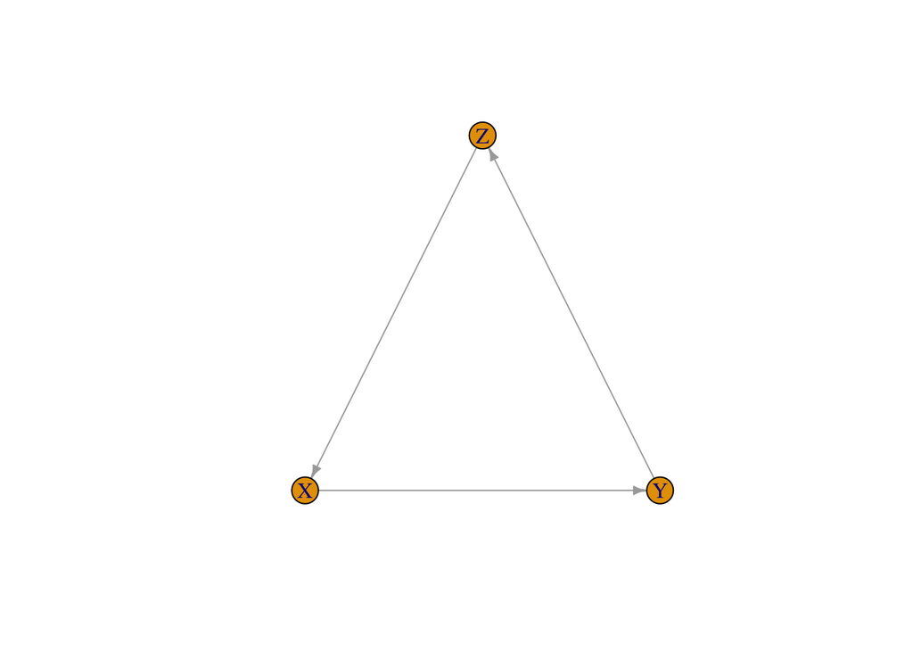

```r
M <- matrix(
  c(0, 1, 0,
    0, 0, 1,
    1, 0, 0),
  nrow = 3, byrow = TRUE,
  dimnames = list(c("X", "Y", "Z"), c("X", "Y", "Z"))
)
g_dir <- graph_from_adjacency_matrix(M, mode = "directed")
plot(g_dir, edge.arrow.size = 0.5)
```

This matrix is not symmetric, so the network is directed. Rows send ties, columns receive them.

## 3. Node attributes

Networks combine relations with attributes. In R, attributes are stored on the nodes:

```r
nodes <- tibble(
  name = c("A", "B", "C", "D", "E"),
  regime = c("democracy", "democracy", "autocracy", "democracy", "autocracy")
)
g <- graph_from_data_frame(edges, directed = FALSE, vertices = nodes)

V(g)$regime
```

```
[1] "democracy" "democracy" "autocracy" "democracy" "autocracy"
```

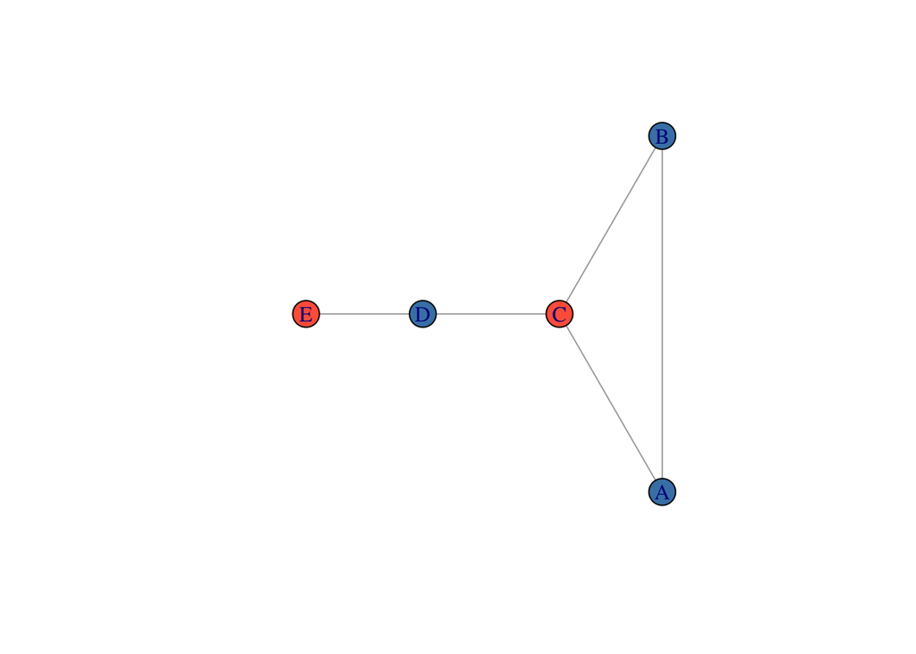

```r
plot(g, vertex.color = ifelse(V(g)$regime == "democracy", "steelblue", "tomato"))
```

## 4. Bipartite networks: states and organisations

Many IR networks link two *different kinds* of nodes, such as states and the international organisations they belong to.

```r
membership <- tribble(
  ~state, ~igo,
  "AUT", "EU",
  "AUT", "UN",
  "DEU", "EU",
  "DEU", "NATO",
  "DEU", "UN",
  "USA", "NATO",
  "USA", "UN"
)

# Incidence matrix: states in rows, organisations in columns
B <- unclass(table(membership$state, membership$igo))
B
```

```
      EU NATO UN
  AUT  1    0  1
  DEU  1    1  1
  USA  0    1  1
```

**NoteThink first**

Compute `B %*% t(B)` by hand. What does each cell tell you about two states? What is on the diagonal?

```r
S <- B %*% t(B)
S
```

```
      AUT DEU USA
  AUT   2   2   1
  DEU   2   3   2
  USA   1   2   2
```

This **projection** gives a state-by-state network weighted by shared memberships:

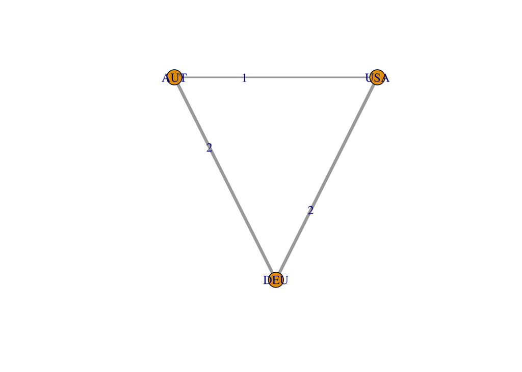

```r
g_states <- graph_from_adjacency_matrix(S, mode = "undirected", weighted = TRUE, diag = FALSE)
plot(g_states, edge.width = E(g_states)$weight * 2, edge.label = E(g_states)$weight)
```

The same in igraph’s own bipartite tools:

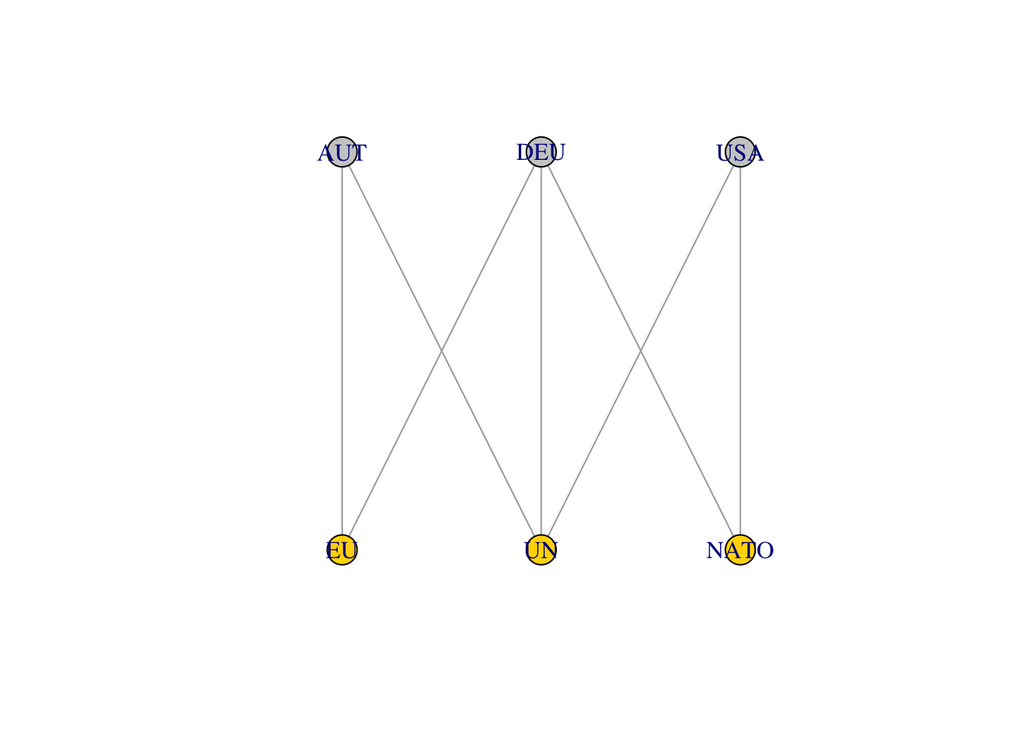

```r
g_bip <- graph_from_data_frame(membership, directed = FALSE)
V(g_bip)$type <- V(g_bip)$name %in% membership$igo
plot(g_bip, layout = layout_as_bipartite, vertex.color = ifelse(V(g_bip)$type, "gold", "grey80"))
```

```r
bipartite_projection(g_bip)
```

```
$proj1
IGRAPH e20255d UNW- 3 3 --
+ attr: name (v/c), weight (e/n)
+ edges from e20255d (vertex names):
[1] AUT--DEU AUT--USA DEU--USA

$proj2
IGRAPH ef76fce UNW- 3 3 --
+ attr: name (v/c), weight (e/n)
+ edges from ef76fce (vertex names):
[1] EU--UN   EU--NATO UN--NATO
```

**WarningDiscuss**

Projection loses information. Which? Think of two states that share membership only in the UN versus two that share the EU.

## 5. Multiplex networks

The same states can be linked by several relations at once. One way to store this is a single edge list with a `layer` column:

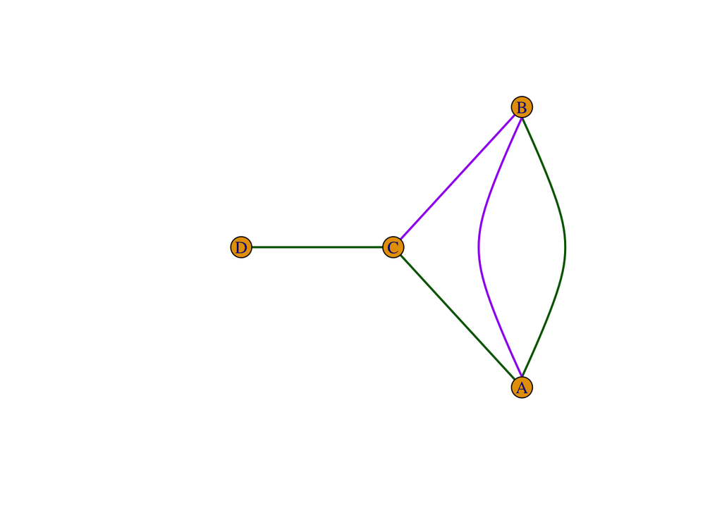

```r
multi <- tribble(
  ~from, ~to, ~layer,
  "A", "B", "trade",
  "A", "C", "trade",
  "B", "C", "alliance",
  "A", "B", "alliance",
  "C", "D", "trade"
)
g_multi <- graph_from_data_frame(multi, directed = FALSE)
plot(g_multi, edge.color = ifelse(E(g_multi)$layer == "trade", "darkgreen", "purple"), edge.width = 2)
```

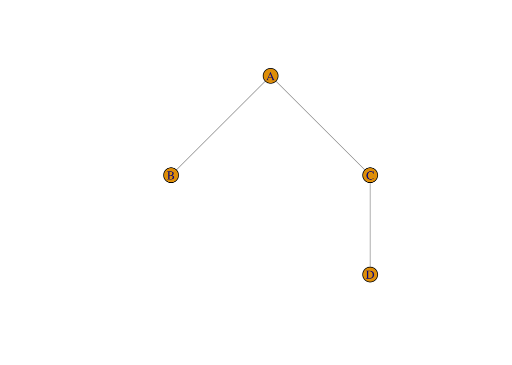

```r
# Extract one layer
g_trade <- subgraph_from_edges(g_multi, E(g_multi)[layer == "trade"])
plot(g_trade)
```

## Your turn

**TipExercise**

1. Write an edge list for a directed network of four states where trade flows go A→B, B→C, C→A and A→D. Convert it to an adjacency matrix and check that row and column sums give out- and in-degree.
2. Extend the `membership` data with two more states and one more organisation. Project it and interpret the strongest tie.
3. Project the bipartite network the *other* way (organisation by organisation). What does a tie mean now?

```r
# your code here
```